# Analysis I

David John Baker

03/06/2020

This document documents the analysis used in **The attraction of predominant chords** by Brown and Tan currently under review at *Music Perception*. The design, construction, collection of data of this experiment was done by Brown and Tan. Baker only assisted in data managment and analysis.

This script re-creates both the figures, tables and anlayses used in the manuscript.

## Data and Library Import

```r
library(readr)
library(stringr)
library(ggplot2)
library(tidyr)
library(GGally)
library(MuMIn)
library(janitor)
library(dplyr)
library(lme4)
library(lmerTest)
library(patchwork)
library(gt)

# Importing Data
## Experimental Data
response_data <- read_csv("tidy_tables/response_data.csv")
chord_stimuli_data <- read_csv("tidy_tables/chord_experiment_stimuli_data.csv")
chord_stimuli_data <- chord_stimuli_data %>%
  rename(chord = chord_symbol,
         chord_family = group)

# Chord Features
chord_features <- read_csv("tidy_tables/chord_features.csv")
chord_features <- janitor::clean_names(chord_features)

chord_features <- chord_features %>%
  separate(col = stimuli, into = c("chord_id","temp"), "\\.") %>%
  separate(col = temp, into = c("chord","notes"), sep = "\\:") %>%
  mutate(chord = str_trim(chord)) %>%
  mutate(notes = str_trim(notes))

# Demographic Data
gmsi <- read_csv("tidy_tables/gmsi_table.csv")
gmsi <- janitor::clean_names(gmsi)
gmsi <- gmsi %>%
  rename(experimental_group = group,
         participant = participant_no)

# Build Big Data
df <- response_data %>%
  pivot_longer(cols = I:`viio7/V`,names_to = "chord",values_to = "rating") %>%
  select(participant, chord, rating, block, group, `How attracted`) %>%
  left_join(chord_stimuli_data) %>%
  left_join(gmsi) %>%
  left_join(chord_features)
```

## Manuscript Recreation

This next section re-creates both the figures and tables used in the manuscript. Only tables that have either response, demographic, or stimuli data are re-created.

### Tables

```r
# Table 3
chord_features %>%
  filter(chord %in% c("I","vi","ii7","viio7/V","Gr6")) %>%
  select(chord, lerdhal_tension, parncut_roughness, semitone_voice_move, rootmotion, number_tendency_tones4_6) %>%
  gt()
```

| chord | lerdhal_tension | parncut_roughness | semitone_voice_move | rootmotion | number_tendency_tones4_6 |
| --- | --- | --- | --- | --- | --- |
| I | 5 | 0.1009 | 1 | 0 | 0 |
| ii7 | 5 | 0.2348 | 1 | 1 | 2 |
| vi | 8 | 0.1012 | 0 | 0 | 1 |
| Gr6 | 7 | 0.2321 | 4 | 0 | 2 |
| viio7/V | 9 | 0.1977 | 3 | 0 | 2 |

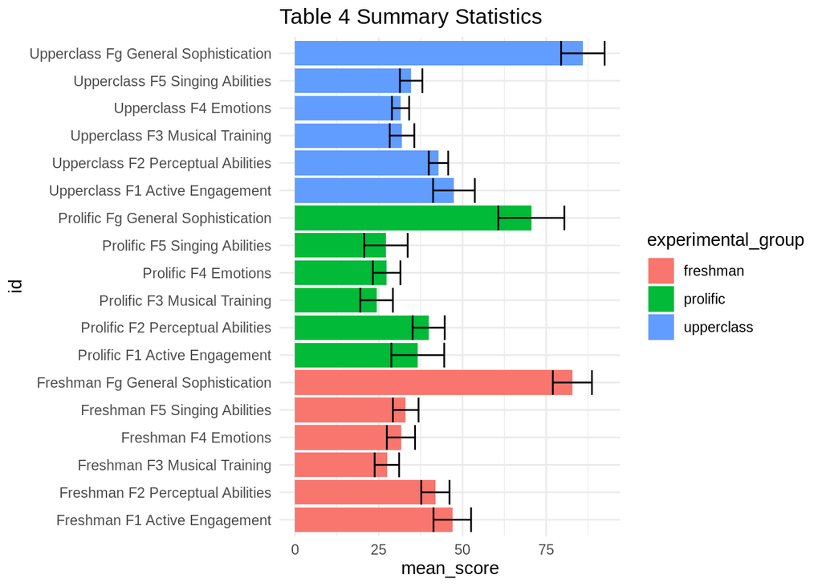

```r
# Table 4
table_4_values <- gmsi %>%
  select(experimental_group, f1_active_engagement:fg_general_sophistication) %>%
  pivot_longer(cols = f1_active_engagement:fg_general_sophistication,
               names_to ="gmsi_score",
               values_to = "score") %>%
  group_by(experimental_group, gmsi_score) %>%
  summarise(mean_score = mean(score),
            sd_score = sd(score)) #%>%
#  pivot_wider(names_from = gmsi_score, values_from = c(mean_score, sd_score))
table_4_values %>%
  mutate(id = paste(experimental_group, gmsi_score)) %>%
  mutate(id = str_replace_all(id, pattern = "_","\\ ")) %>%
  mutate(id = str_to_title(id)) %>%
  ggplot(aes(x = id, y = mean_score, fill = experimental_group)) +
  geom_bar(stat = "identity") +
  geom_errorbar(aes(ymin = mean_score-sd_score, ymax = mean_score + sd_score)) +
  theme_minimal() +
  coord_flip() +
  labs(title = "Table 4 Summary Statistics")
```

```r
# Table 6 Mean Ratings Per Chord Per Group
df %>%
  select(chord_family, chord, rating, experimental_group) %>%
  group_by(chord, experimental_group) %>%
  summarise(mean_rating = mean(rating),
            sd_rating = sd(rating))
```

```
## # A tibble: 93 x 4
## # Groups:   chord [31]
##    chord experimental_group mean_rating sd_rating
##    <chr> <chr>                    <dbl>     <dbl>
##  1 Fr6   freshman                  4.87     1.44
##  2 Fr6   prolific                  3.86     1.64
##  3 Fr6   upperclass                5.60     1.27
##  4 Ger6  freshman                  5.24     1.27
##  5 Ger6  prolific                  4.32     1.39
##  6 Ger6  upperclass                5.91     0.897
##  7 i     freshman                  4.66     1.55
##  8 i     prolific                  4.69     1.52
##  9 i     upperclass                4.92     1.48
## 10 I     freshman                  4.48     1.76
## # … with 83 more rows
```

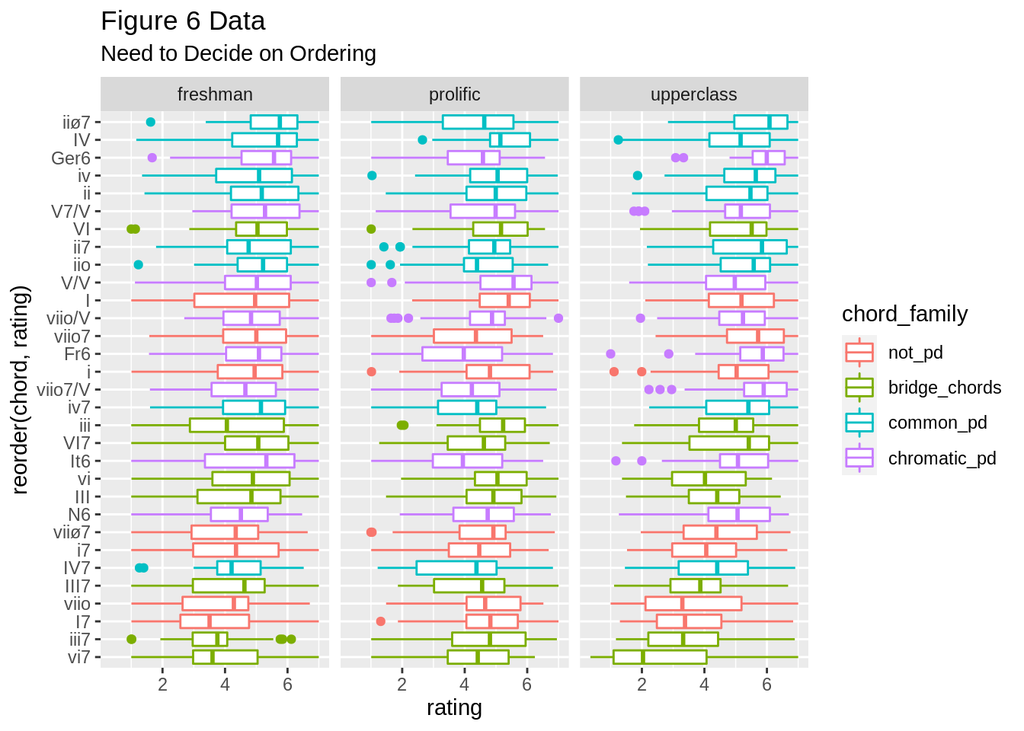

```r
df %>%
  select(chord_family, chord, rating, experimental_group) %>%
  mutate(chord_family = factor(chord_family, levels = c("not_pd","bridge_chords","common_pd","chromatic_pd"))) %>%
  ggplot(aes(x = reorder(chord, rating), color = chord_family, y = rating)) +
  geom_boxplot() +
  facet_wrap(~experimental_group) +
  coord_flip() +
  labs(title = "Figure 6 Data",
       subtitle = "Need to Decide on Ordering")
```

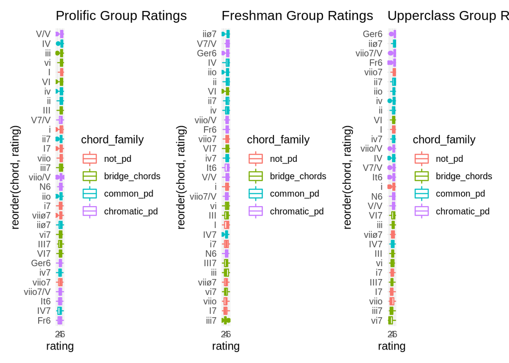

```r
## Re-Ordered Paneling
prolific_panel <- df %>%
  filter(experimental_group == "prolific") %>%
  select(chord_family, chord, rating, experimental_group) %>%
  mutate(chord_family = factor(chord_family, levels = c("not_pd","bridge_chords","common_pd","chromatic_pd"))) %>%
  ggplot(aes(x = reorder(chord, rating), color = chord_family, y = rating)) +
  geom_boxplot() +
  coord_flip() +
  theme_minimal() +
  labs(title = "Prolific Group Ratings")

freshman_panel <- df %>%
  filter(experimental_group == "freshman") %>%
  select(chord_family, chord, rating, experimental_group) %>%
  mutate(chord_family = factor(chord_family, levels = c("not_pd","bridge_chords","common_pd","chromatic_pd"))) %>%
  ggplot(aes(x = reorder(chord, rating), color = chord_family, y = rating)) +
  geom_boxplot() +
  coord_flip() +
  theme_minimal() +
  labs(title = "Freshman Group Ratings")

upperclass_panel <- df %>%
  filter(experimental_group == "upperclass") %>%
  select(chord_family, chord, rating, experimental_group) %>%
  mutate(chord_family = factor(chord_family, levels = c("not_pd","bridge_chords","common_pd","chromatic_pd"))) %>%
  ggplot(aes(x = reorder(chord, rating), color = chord_family, y = rating)) +
  geom_boxplot() +
  coord_flip() +
  theme_minimal() +
  labs(title = "Upperclass Group Ratings", xlab = "")

prolific_panel + freshman_panel + upperclass_panel
```

```r
# Table 7 - tables needs reordering
chord_features %>%
  filter(chord %in% c("I","vi","ii7","viio7/V","Gr6")) %>%
  select(chord, x4_6, x4_b6, number_4_b6, number_4_6) %>%
  distinct()
```

```
## # A tibble: 5 x 5
##   chord    x4_6 x4_b6 number_4_b6 number_4_6
##   <chr>   <dbl> <dbl>       <dbl>      <dbl>
## 1 I           0     0           0          0
## 2 ii7         1     0           0          0
## 3 vi          0     0           0          0
## 4 Gr6         0     0           1          0
## 5 viio7/V     0     0           0          1
```

### Figures

- Figure 4

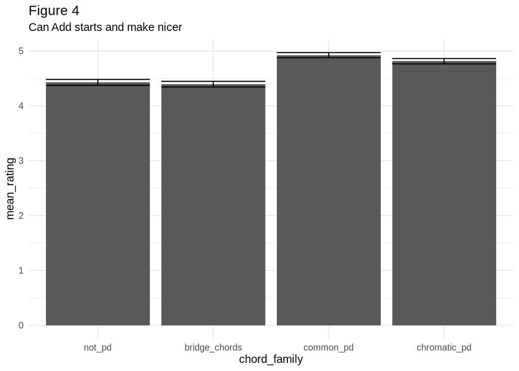

```r
df$chord_family <- factor(df$chord_family, levels = c("not_pd","bridge_chords","common_pd","chromatic_pd"))

std <- function(x) sd(x)/sqrt(length(x))

# Figure 4
df %>%
  select(chord_family, rating, group) %>%
  group_by(chord_family) %>%
  summarise(mean_rating = mean(rating),
            sd_rating = sd(rating),
            std_rating = std(rating)) %>%
  ggplot(aes(x = chord_family, y = mean_rating)) +
  geom_bar(stat = "identity") +
  geom_errorbar(aes(ymin = mean_rating - std_rating, ymax = mean_rating + std_rating)) +
  labs(title = "Figure 4",
       subtitle = "Can Add starts and make nicer") +
  theme_minimal()
```

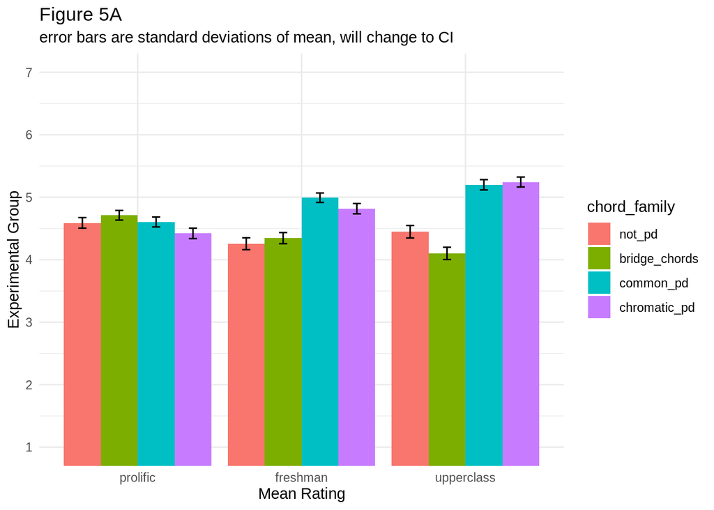

```r
# Figure 5 A
df %>%
  select(chord_family, rating, group, experimental_group) %>%
  mutate(experimental_group = factor(experimental_group, levels = c("prolific","freshman","upperclass"))) %>%
  group_by(chord_family, experimental_group) %>%
  summarise(mean_rating = mean(rating),
            sd_rating = sd(rating),
            std_rating = std(rating)) %>%
  ggplot(aes(x = experimental_group,
             y = mean_rating,
             fill = chord_family)) +
  geom_bar(position = "dodge", stat = "identity") +
  geom_errorbar(
    aes(ymin = mean_rating - std_rating,
        ymax = mean_rating + std_rating),
    width = 0.2,
    position = position_dodge(width = 0.9)) +
  coord_cartesian(ylim=c(1,7)) +
  scale_y_continuous(breaks = seq(1, 7, by = 1)) +
  labs(title = "Figure 5A",
       subtitle = "error bars are standard deviations of mean, will change to CI",
       x = "Mean Rating",
       y = "Experimental Group") +
  theme_minimal()
```

```r
# Grouped Mean Attraction by Musical Training
# mean_ratings_participants <- df %>%
#   select(participant, rating, chord_family, block_index) %>%
#   group_by(participant, block_index) %>%
#   summarise(mean_score = mean(rating)) %>%
#   ungroup(participant)
#
# mean_ratings_participants
#
# mean_ratings_participants %>%
#   left_join(gmsi) %>%
#   left_join(chord_stimuli_data) %>%
#   select(participant, mean_score, chord_family, f3_musical_training) %>%
#   print(n = 100)
```

## Modeling

### Musical Training Subscale Questions

In this next section of the notebook, we document choices made for the regression modeling.

First, we inspect the distribution of the `I have had formal training in music theory for X years` question to see if this seven point Likert scale better captures the distribution of musical training compared to using a categorical predictor. We do this per suggestion of Harrell, 2019 `Regression Modeling Strategies`.

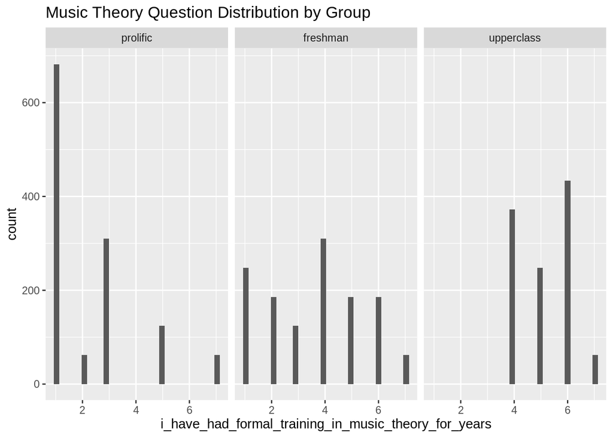

```r
df %>%
  select(i_have_had_formal_training_in_music_theory_for_years, group) %>%
  mutate(group = factor(group, c("prolific","freshman","upperclass"))) %>%
  ggplot(aes(x = i_have_had_formal_training_in_music_theory_for_years)) +
  geom_histogram() +
  facet_wrap(~group) +
  labs(title = "Music Theory Question Distribution by Group")
```

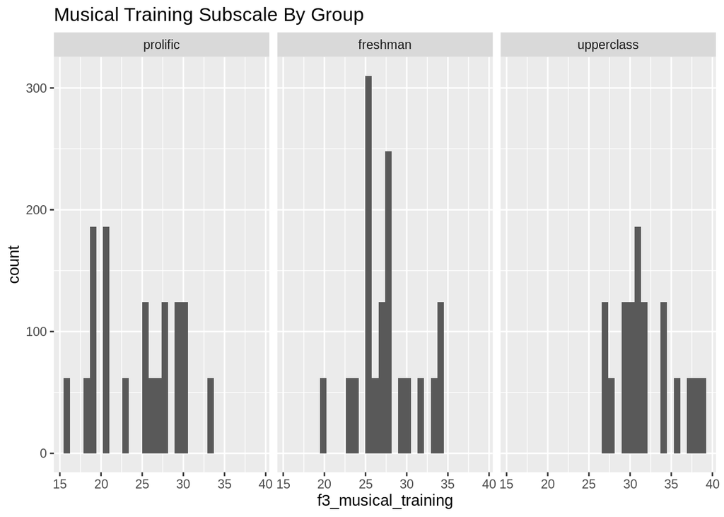

```r
df %>%
  select(f3_musical_training, group) %>%
  mutate(group = factor(group, c("prolific","freshman","upperclass"))) %>%
  ggplot(aes(x = f3_musical_training)) +
  geom_histogram() +
  facet_wrap(~group) +
  labs(title = "Musical Training Subscale By Group")
```

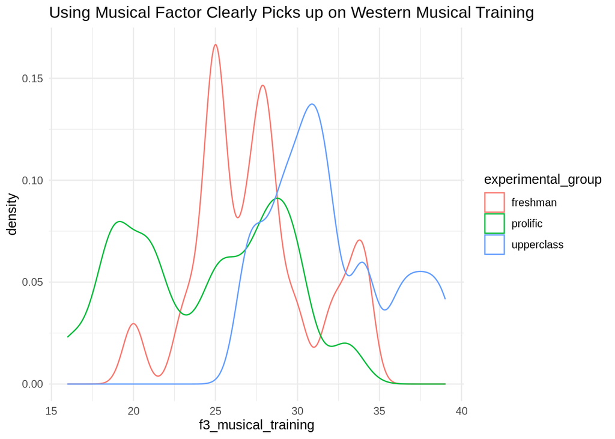

```r
df %>%
  ggplot(aes(x = f3_musical_training, color = experimental_group)) +
  geom_density() +
  theme_minimal() +
  labs(title = "Using Musical Factor Clearly Picks up on Western Musical Training")
```

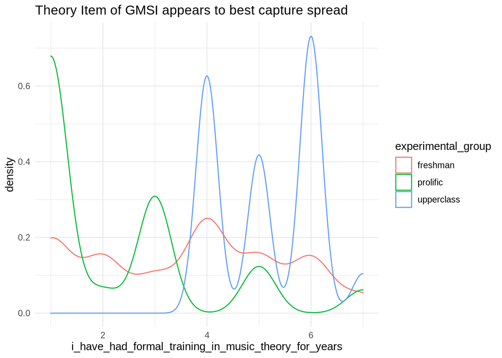

```r
df %>%
  ggplot(aes(x = i_have_had_formal_training_in_music_theory_for_years, color = experimental_group)) +
  geom_density() +
  theme_minimal() +
  labs(title = "Theory Item of GMSI appears to best capture spread")
```

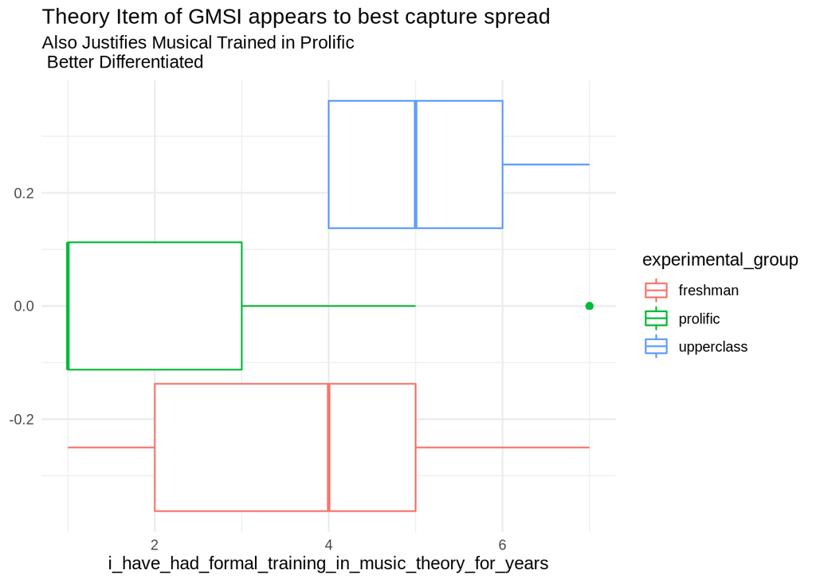

```r
# And Collapsed to see pattern better
df %>%
  ggplot(aes(x = i_have_had_formal_training_in_music_theory_for_years, color = experimental_group)) +
  geom_boxplot() +
  theme_minimal() +
  labs(title = "Theory Item of GMSI appears to best capture spread",
       subtitle = "Also Justifies Musical Trained in Prolific\n Better Differentiated")
```

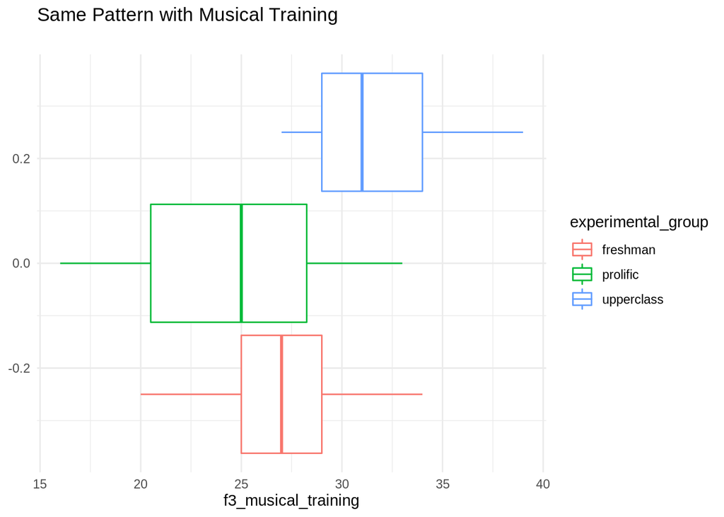

```r
df %>%
  ggplot(aes(x = f3_musical_training, color = experimental_group)) +
  geom_boxplot() +
  theme_minimal() +
  labs(title = "Same Pattern with Musical Training",
       subtitle = "")
```

It appears that pattern is same with GMSI and Theory Question, going to decide to use the Theory question so that it picks up on idea of specific training, not peripherial learning.

### Hierarchical Modeling

The dependent variable in all modeling was the `rating` variables. As per the design in the text, the experiment used a crossed design meaning that all participants rated all stimuli. Stimuli were all rated twice, once in each block.

In order to first explore how much of the variation in the dependent variable was due to individual differences, we first ran a null model that consisted of of predicting variation in `rating` DV with both participant and block as random effects.

```r
# Select Individual Model Data
model_data <- df %>%
  select(rating,
         chord_family,
         participant,
         block,
         i_have_had_formal_training_in_music_theory_for_years,
         f3_musical_training,experimental_group) %>%
  mutate(experimental_group = factor(experimental_group, c("prolific", "freshman","upperclass")))

# Run Null Model
null_model <- lmer(rating ~ (1|participant) + (1|block), data = model_data)
null_summary <- summary(null_model)
null_summary
```

```
## Linear mixed model fit by REML. t-tests use Satterthwaite's method [
## lmerModLmerTest]
## Formula: rating ~ (1 | participant) + (1 | block)
##    Data: model_data
##
## REML criterion at convergence: 12841.3
##
## Scaled residuals:
##     Min      1Q  Median      3Q     Max
## -3.2894 -0.6047  0.0866  0.7197  3.2681
##
## Random effects:
##  Groups      Name        Variance  Std.Dev.
##  participant (Intercept) 0.4756497 0.68967
##  block       (Intercept) 0.0003334 0.01826
##  Residual                1.8710928 1.36788
## Number of obs: 3658, groups:  participant, 59; block, 2
##
## Fixed effects:
##             Estimate Std. Error       df t value Pr(>|t|)
## (Intercept)  4.64689    0.09349 44.22418   49.71   <2e-16 ***
## ---
## Signif. codes:  0 '***' 0.001 '**' 0.01 '*' 0.05 '.' 0.1 ' ' 1
```

```r
print(paste(round(.47/(.47+1.87)*100,3),"% of the data is explained with null model"))
```

```
## [1] "20.085 % of the data is explained with null model"
```

```r
print("Variation due to block is negligable")
```

```
## [1] "Variation due to block is negligable"
```

Running the null model, we were able to account for 20% of the variation in response due solely to response in the participants. Of this 20%, a negligible amount was due to block from which we can conclude there were no effects of block. This variable was not used for subsequent analyses.

After the null model, we then ran a model that that listed `chord_family` as a fixed effect. Since the manuscript theorized that there is something special about chord function/family, chord family was a fixed effect which allowed random intercepts.

```r
# Chord with Random Intercept
chord_category_model <- lmer(rating ~ chord_family + (1|participant), data = model_data)
summary(chord_category_model)
```

```
## Linear mixed model fit by REML. t-tests use Satterthwaite's method [
## lmerModLmerTest]
## Formula: rating ~ chord_family + (1 | participant)
##    Data: model_data
##
## REML criterion at convergence: 12745.6
##
## Scaled residuals:
##     Min      1Q  Median      3Q     Max
## -3.1472 -0.6277  0.0611  0.7153  3.1832
##
## Random effects:
##  Groups      Name        Variance Std.Dev.
##  participant (Intercept) 0.4765   0.6903
##  Residual                1.8177   1.3482
## Number of obs: 3658, groups:  participant, 59
##
## Fixed effects:
##                             Estimate Std. Error         df t value Pr(>|t|)
## (Intercept)                  4.42756    0.10138   83.28867  43.675  < 2e-16 ***
## chord_familybridge_chords   -0.03238    0.06423 3596.00000  -0.504    0.614
## chord_familycommon_pd        0.49659    0.06423 3596.00000   7.731 1.38e-14 ***
## chord_familychromatic_pd     0.38572    0.06423 3596.00000   6.005 2.11e-09 ***
## ---
## Signif. codes:  0 '***' 0.001 '**' 0.01 '*' 0.05 '.' 0.1 ' ' 1
##
## Correlation of Fixed Effects:
##              (Intr) chrd_fmlyb_ chrd_fmlycm_
## chrd_fmlyb_  -0.338
## chrd_fmlycm_ -0.338  0.533
## chrd_fmlych_ -0.338  0.533       0.533
```

```r
# Significantly better with chord family in model
anova(null_model, chord_category_model)
```

```
## refitting model(s) with ML (instead of REML)
```

```
## Data: model_data
## Models:
## null_model: rating ~ (1 | participant) + (1 | block)
## chord_category_model: rating ~ chord_family + (1 | participant)
##                      npar   AIC   BIC  logLik deviance  Chisq Df Pr(>Chisq)
## null_model              4 12846 12871 -6419.2    12838
## chord_category_model    6 12743 12780 -6365.4    12731 107.51  2  < 2.2e-16 ***
## ---
## Signif. codes:  0 '***' 0.001 '**' 0.01 '*' 0.05 '.' 0.1 ' ' 1
```

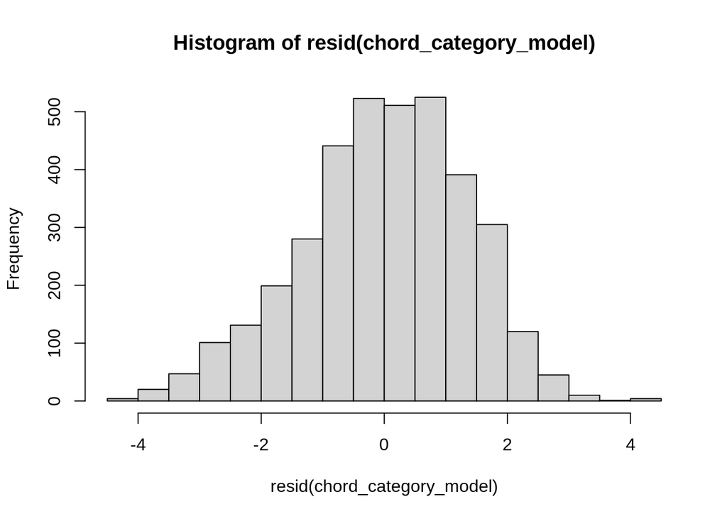

```r
# Residuals were normally distributed
hist(resid(chord_category_model))
```

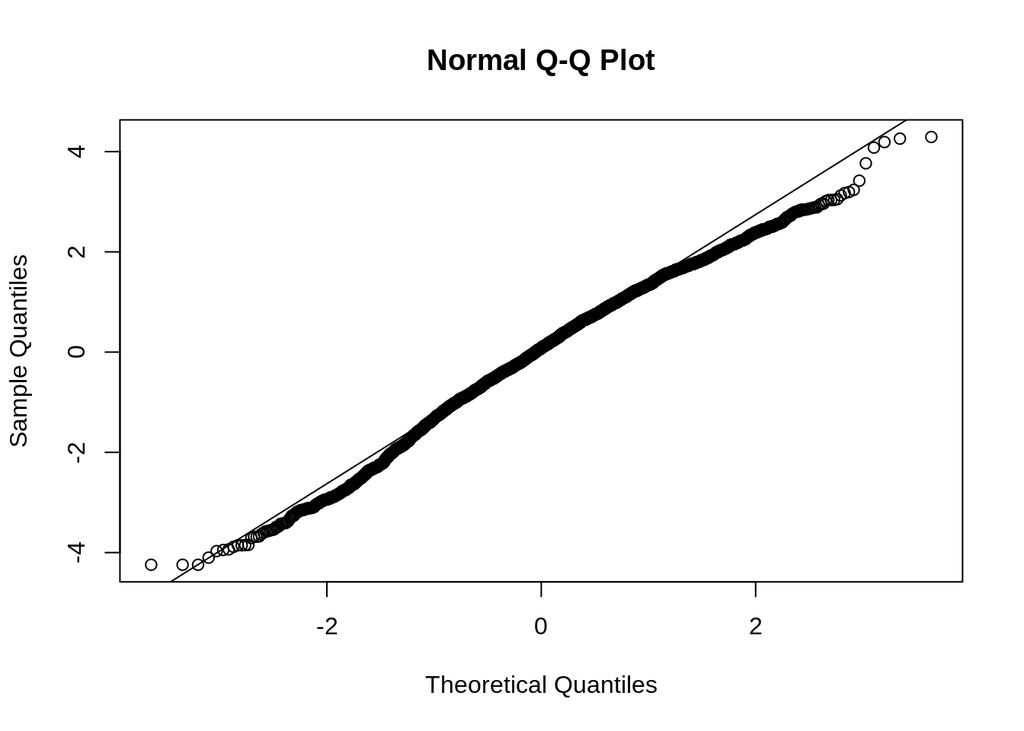

```r
qqnorm(resid(chord_category_model))
qqline(resid(chord_category_model))
```

```r
r.squaredGLMM(null_model)
```

```
##      R2m       R2c
## [1,]   0 0.2027983
```

```r
r.squaredGLMM(chord_category_model)
```

```
##             R2m       R2c
## [1,] 0.02308405 0.2259916
```

Results from using `chord_family` as a fixed effect resulted in a signifcantly better model fit (see Chi Squared, AIC, BIC) and improved R2 by 2%. Results here mirror results from Figure 4 from the original manuscript.

Seeing as we hypothesized that musical training will influence rating, we then decided to add random slopes. Our current model forced each participant to rate all chord family data with the same pattern.

This means that we expect participants when rating chord families to exhibit the same relationship between chord family and chord rating, although we acknowledge that some populations rate chords differently.

If we were to allow chord family to have a random slope, ratings from within the chord family participant could help???

# particpiant as random effect

# gmsi as fixed effect and random slope with chord family.

```r
# Chord Random Slopes
chord_category_model_random_slopes <- lmer(rating ~ chord_family + (1+ chord_family | participant), data = model_data, REML = TRUE)
```

```
## boundary (singular) fit: see ?isSingular
```

```r
(ccmrs_summary <- summary(chord_category_model_random_slopes))
```

```
## Linear mixed model fit by REML. t-tests use Satterthwaite's method [
## lmerModLmerTest]
## Formula: rating ~ chord_family + (1 + chord_family | participant)
##    Data: model_data
##
## REML criterion at convergence: 12616.2
##
## Scaled residuals:
##     Min      1Q  Median      3Q     Max
## -3.3796 -0.6059  0.0691  0.6881  3.1387
##
## Random effects:
##  Groups      Name                      Variance  Std.Dev. Corr
##  participant (Intercept)               0.5418090 0.73608
##              chord_familybridge_chords 0.0002885 0.01698  -1.00
##              chord_familycommon_pd     0.3800122 0.61645  -0.35  0.35
##              chord_familychromatic_pd  0.5161328 0.71842  -0.31  0.31  0.83
##  Residual                              1.6961279 1.30235
## Number of obs: 3658, groups:  participant, 59
##
## Fixed effects:
##                             Estimate Std. Error         df t value Pr(>|t|)
## (Intercept)                  4.42756    0.10600   58.47360  41.768  < 2e-16 ***
## chord_familybridge_chords   -0.03238    0.06209 2973.01387  -0.522  0.60205
## chord_familycommon_pd        0.49659    0.10144   70.36210   4.895 6.03e-06 ***
## chord_familychromatic_pd     0.38572    0.11224   65.83747   3.437  0.00103 **
## ---
## Signif. codes:  0 '***' 0.001 '**' 0.01 '*' 0.05 '.' 0.1 ' ' 1
##
## Correlation of Fixed Effects:
##              (Intr) chrd_fmlyb_ chrd_fmlycm_
## chrd_fmlyb_  -0.344
## chrd_fmlycm_ -0.438  0.336
## chrd_fmlych_ -0.409  0.304       0.731
## convergence code: 0
## boundary (singular) fit: see ?isSingular
```

```r
(.54+.0002+.38+.51)/(.54+.0002+.38+.51+1.69)
```

```
## [1] 0.4583681
```

```r
ccmrs_summary$coefficients[,1]
```

```
##               (Intercept) chord_familybridge_chords     chord_familycommon_pd
##                4.42755569               -0.03237984                0.49659050
##  chord_familychromatic_pd
##                0.38572185
```

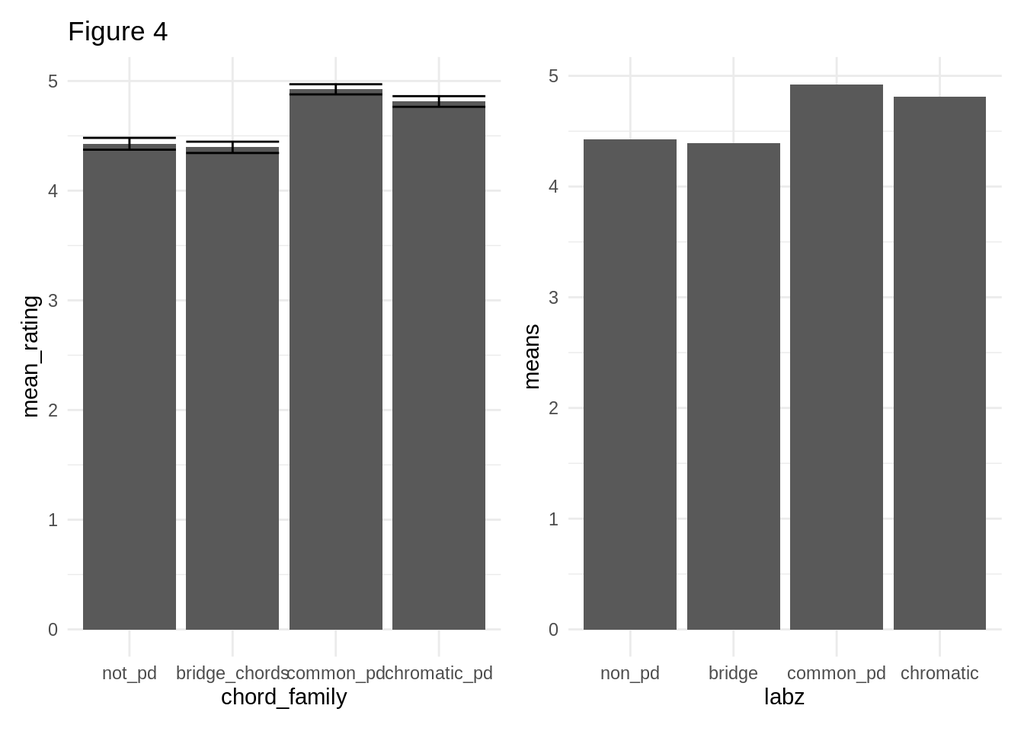

```r
means <- tibble(means = c(4.42755569,4.42755569+-0.0323784,4.42755569+.49659050,4.42755569+0.38572185),
                labz = c("non_pd","bridge","common_pd","chromatic"))

means %>%
  mutate(labz = factor(labz, levels = c("non_pd","bridge","common_pd","chromatic"))) %>%
  ggplot(aes(y = means, x = labz)) +
  geom_bar(stat = "identity") +
  theme_minimal()-> random_slopes_plot_1

df %>%
  select(chord_family, rating, group) %>%
  group_by(chord_family) %>%
  summarise(mean_rating = mean(rating),
            sd_rating = sd(rating),
            std_rating = std(rating)) %>%
  ggplot(aes(x = chord_family, y = mean_rating)) +
  geom_bar(stat = "identity") +
  geom_errorbar(aes(ymin = mean_rating - std_rating, ymax = mean_rating + std_rating)) +
  labs(title = "Figure 4") +
  theme_minimal() -> unadjusted_means_1
unadjusted_means_1 + random_slopes_plot_1
```

```r
# Significantly better with chord family in model
anova(null_model, chord_category_model, chord_category_model_random_slopes)
```

```
## refitting model(s) with ML (instead of REML)
```

```
## Data: model_data
## Models:
## null_model: rating ~ (1 | participant) + (1 | block)
## chord_category_model: rating ~ chord_family + (1 | participant)
## chord_category_model_random_slopes: rating ~ chord_family + (1 + chord_family | participant)
##                                    npar   AIC   BIC  logLik deviance  Chisq Df
## null_model                            4 12846 12871 -6419.2    12838
## chord_category_model                  6 12743 12780 -6365.4    12731 107.51  2
## chord_category_model_random_slopes   15 12633 12726 -6301.7    12603 127.48  9
##                                    Pr(>Chisq)
## null_model
## chord_category_model                < 2.2e-16 ***
## chord_category_model_random_slopes  < 2.2e-16 ***
## ---
## Signif. codes:  0 '***' 0.001 '**' 0.01 '*' 0.05 '.' 0.1 ' ' 1
```

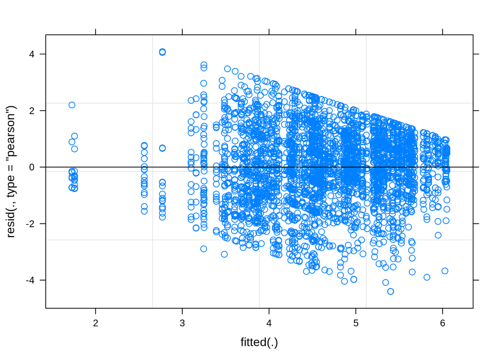

```r
# Again Residuals Fine
plot(chord_category_model_random_slopes)
```

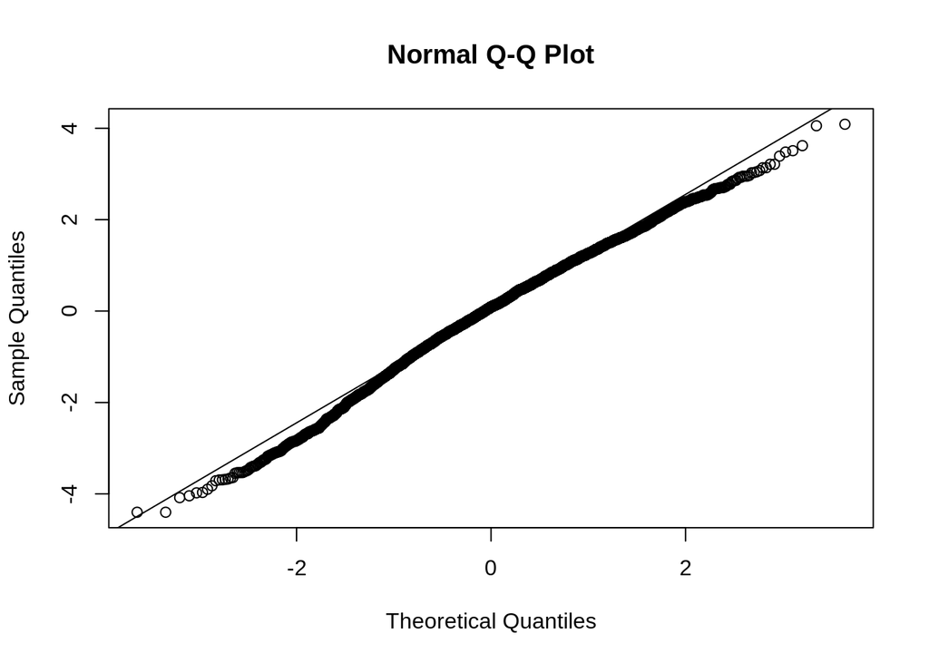

```r
qqnorm(resid(chord_category_model_random_slopes))
qqline(resid(chord_category_model_random_slopes))
```

Allowing for random slopes of chord category increased R2 to 46%. Model fit also significantly improved.

- [ ] Make Plot Here of Slopes per group!

Check here if more interpreatlbe to put individual as random effect and let musical training level be the random slope as random effect.

Going to add in musical training with theory as model

```r
musical_individual_model <- lmer(rating ~ chord_family  +
                                   (1+ i_have_had_formal_training_in_music_theory_for_years |participant),
                                 data = model_data)

summary(musical_individual_model)
```

```
## Linear mixed model fit by REML. t-tests use Satterthwaite's method [
## lmerModLmerTest]
## Formula:
## rating ~ chord_family + (1 + i_have_had_formal_training_in_music_theory_for_years |
##     participant)
##    Data: model_data
##
## REML criterion at convergence: 12739.5
##
## Scaled residuals:
##     Min      1Q  Median      3Q     Max
## -3.1488 -0.6322  0.0572  0.7183  3.2243
##
## Random effects:
##  Groups      Name                                                 Variance
##  participant (Intercept)                                          1.30394
##              i_have_had_formal_training_in_music_theory_for_years 0.06763
##  Residual                                                         1.81769
##  Std.Dev. Corr
##  1.1419
##  0.2601   -0.91
##  1.3482
## Number of obs: 3658, groups:  participant, 59
##
## Fixed effects:
##                             Estimate Std. Error         df t value Pr(>|t|)
## (Intercept)                  4.46441    0.09262   71.88686  48.203  < 2e-16 ***
## chord_familybridge_chords   -0.03238    0.06423 3596.00041  -0.504    0.614
## chord_familycommon_pd        0.49659    0.06423 3596.00041   7.731 1.38e-14 ***
## chord_familychromatic_pd     0.38572    0.06423 3596.00041   6.005 2.11e-09 ***
## ---
## Signif. codes:  0 '***' 0.001 '**' 0.01 '*' 0.05 '.' 0.1 ' ' 1
##
## Correlation of Fixed Effects:
##              (Intr) chrd_fmlyb_ chrd_fmlycm_
## chrd_fmlyb_  -0.370
## chrd_fmlycm_ -0.370  0.533
## chrd_fmlych_ -0.370  0.533       0.533
```

```r
(1.30+0.06)/(1.30+0.06+1.81)
```

```
## [1] 0.4290221
```

```r
anova(chord_category_model_random_slopes,musical_individual_model)
```

```
## refitting model(s) with ML (instead of REML)
```

```
## Data: model_data
## Models:
## musical_individual_model: rating ~ chord_family + (1 + i_have_had_formal_training_in_music_theory_for_years |
## musical_individual_model:     participant)
## chord_category_model_random_slopes: rating ~ chord_family + (1 + chord_family | participant)
##                                    npar   AIC   BIC  logLik deviance  Chisq Df
## musical_individual_model              8 12740 12790 -6362.3    12724
## chord_category_model_random_slopes   15 12633 12726 -6301.7    12603 121.14  7
##                                    Pr(>Chisq)
## musical_individual_model
## chord_category_model_random_slopes  < 2.2e-16 ***
## ---
## Signif. codes:  0 '***' 0.001 '**' 0.01 '*' 0.05 '.' 0.1 ' ' 1
```

Appears Musical Training does not help as much

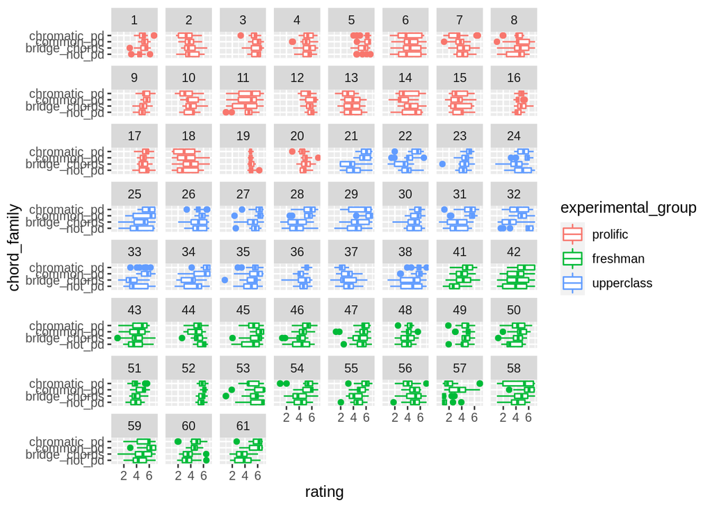

```r
# Re-Do This with ordered Data on musical training ???
model_data %>%
  ggplot(aes(y = rating, x = chord_family, color = experimental_group)) +
  geom_boxplot() +
  facet_wrap(~participant) +
  coord_flip()
```

### Musical Data

We next ran the model with just the musical data.

```r
musical_model_data <- df %>%
  select(rating, chord,  chord_family, participant,
         block, chord_id:major_minor_chromatic, experimental_group, i_have_had_formal_training_in_music_theory_for_years, f3_musical_training) %>%
  mutate(experimental_group = factor(experimental_group, c("prolific", "freshman","upperclass")))

# # Featuers are not super correlated with one another, very good!
# musical_model_data %>%
#   select(chord_family, parncut_roughness:number_tendency_tones4_6) %>%
#   ggpairs(aes(color = chord_family))

# Run Parncut Only Model
parncutt_only_model <- lmer(scale(rating) ~ scale(parncut_roughness) + (1+scale(parncut_roughness)|participant), data = musical_model_data)
summary(parncutt_only_model)
```

```
## Linear mixed model fit by REML. t-tests use Satterthwaite's method [
## lmerModLmerTest]
## Formula:
## scale(rating) ~ scale(parncut_roughness) + (1 + scale(parncut_roughness) |
##     participant)
##    Data: musical_model_data
##
## REML criterion at convergence: 8663.2
##
## Scaled residuals:
##     Min      1Q  Median      3Q     Max
## -3.2493 -0.6111  0.0615  0.6954  3.4528
##
## Random effects:
##  Groups      Name                     Variance Std.Dev. Corr
##  participant (Intercept)              0.20259  0.4501
##              scale(parncut_roughness) 0.04468  0.2114   -0.05
##  Residual                             0.74535  0.8633
## Number of obs: 3304, groups:  participant, 59
##
## Fixed effects:
##                          Estimate Std. Error       df t value Pr(>|t|)
## (Intercept)              -0.01578    0.06049 57.99990  -0.261 0.795117
## scale(parncut_roughness) -0.12635    0.03135 58.00007  -4.030 0.000165 ***
## ---
## Signif. codes:  0 '***' 0.001 '**' 0.01 '*' 0.05 '.' 0.1 ' ' 1
##
## Correlation of Fixed Effects:
##             (Intr)
## scl(prnct_) -0.043
```

```r
all_musical_model <- lmer(rating ~
                            lerdhal_tension +
                            parncut_roughness +
                            semitone_voice_move +
                            rootmotion +
                            number_tendency_tones4_6 +
                            (1|participant),
                          data = musical_model_data)

all_musical_model_summary <- summary(all_musical_model)
all_musical_model_summary
```

```
## Linear mixed model fit by REML. t-tests use Satterthwaite's method [
## lmerModLmerTest]
## Formula: rating ~ lerdhal_tension + parncut_roughness + semitone_voice_move +
##     rootmotion + number_tendency_tones4_6 + (1 | participant)
##    Data: musical_model_data
##
## REML criterion at convergence: 11486.7
##
## Scaled residuals:
##      Min       1Q   Median       3Q      Max
## -3.01000 -0.61424  0.04111  0.70483  3.12747
##
## Random effects:
##  Groups      Name        Variance Std.Dev.
##  participant (Intercept) 0.473    0.6877
##  Residual                1.793    1.3390
## Number of obs: 3304, groups:  participant, 59
##
## Fixed effects:
##                            Estimate Std. Error         df t value Pr(>|t|)
## (Intercept)               4.686e+00  1.484e-01  3.675e+02  31.583  < 2e-16 ***
## lerdhal_tension           2.045e-03  1.569e-02  3.240e+03   0.130 0.896311
## parncut_roughness        -2.802e+00  3.322e-01  3.240e+03  -8.436  < 2e-16 ***
## semitone_voice_move       1.323e-01  2.743e-02  3.240e+03   4.821 1.49e-06 ***
## rootmotion                3.614e-01  7.162e-02  3.240e+03   5.047 4.73e-07 ***
## number_tendency_tones4_6  1.218e-01  3.187e-02  3.240e+03   3.821 0.000136 ***
## ---
## Signif. codes:  0 '***' 0.001 '**' 0.01 '*' 0.05 '.' 0.1 ' ' 1
##
## Correlation of Fixed Effects:
##             (Intr) lrdhl_ prnct_ smtn__ rotmtn
## lerdhl_tnsn -0.637
## prnct_rghns -0.459  0.209
## semtn_vc_mv  0.106 -0.306 -0.356
## rootmotion  -0.136  0.143  0.002  0.276
## nmbr_tn_4_6 -0.018 -0.247  0.065 -0.224 -0.481
```

```r
r.squaredGLMM(null_model)
```

```
##      R2m       R2c
## [1,]   0 0.2027983
```

```r
r.squaredGLMM(all_musical_model)
```

```
##             R2m       R2c
## [1,] 0.03960022 0.2400601
```

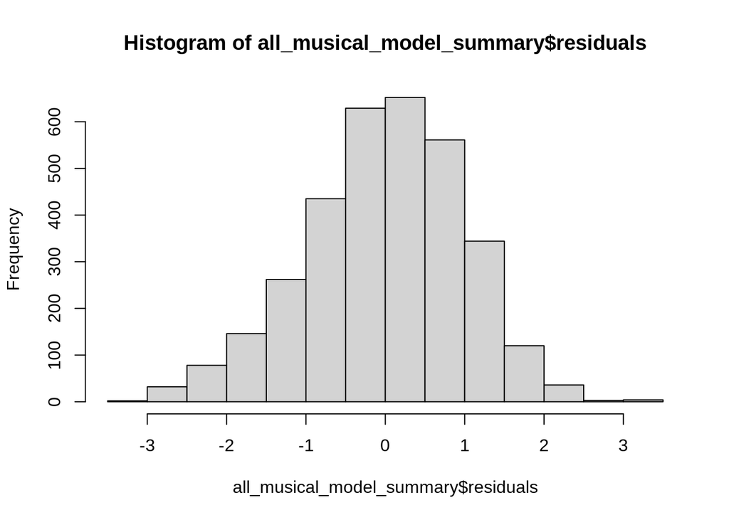

```r
hist(all_musical_model_summary$residuals)
```

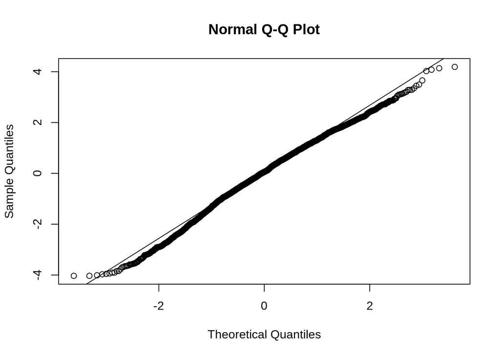

```r
qqnorm(resid(all_musical_model))
qqline(resid(all_musical_model))
```

```r
all_musical_indv_theory_model <- lmer(rating ~
                               chord_family +
                            lerdhal_tension +
                            parncut_roughness +
                            semitone_voice_move +
                            rootmotion +
                            number_tendency_tones4_6 +
                             i_have_had_formal_training_in_music_theory_for_years +
                            (1+ chord_family|participant),
                          data = musical_model_data)
summary(all_musical_indv_theory_model)
```

```
## Linear mixed model fit by REML. t-tests use Satterthwaite's method [
## lmerModLmerTest]
## Formula: rating ~ chord_family + lerdhal_tension + parncut_roughness +
##     semitone_voice_move + rootmotion + number_tendency_tones4_6 +
##     i_have_had_formal_training_in_music_theory_for_years + (1 +
##     chord_family | participant)
##    Data: musical_model_data
##
## REML criterion at convergence: 11379.8
##
## Scaled residuals:
##     Min      1Q  Median      3Q     Max
## -3.2131 -0.5994  0.0508  0.6668  3.1071
##
## Random effects:
##  Groups      Name                      Variance Std.Dev. Corr
##  participant (Intercept)               0.57419  0.7578
##              chord_familybridge_chords 0.04747  0.2179   -0.22
##              chord_familycommon_pd     0.28537  0.5342   -0.33 -0.17
##              chord_familychromatic_pd  0.44141  0.6644   -0.32 -0.26  0.71
##  Residual                              1.66428  1.2901
## Number of obs: 3304, groups:  participant, 59
##
## Fixed effects:
##                                                        Estimate Std. Error
## (Intercept)                                             4.42857    0.24571
## chord_familybridge_chords                              -0.15056    0.10837
## chord_familycommon_pd                                  -0.08861    0.15926
## chord_familychromatic_pd                               -0.34509    0.17834
## lerdhal_tension                                         0.04053    0.02629
## parncut_roughness                                      -2.80605    0.33577
## semitone_voice_move                                     0.15635    0.02988
## rootmotion                                              0.41511    0.07949
## number_tendency_tones4_6                                0.15216    0.05198
## i_have_had_formal_training_in_music_theory_for_years    0.01996    0.04731
##                                                              df t value
## (Intercept)                                           136.48297  18.024
## chord_familybridge_chords                             318.41725  -1.389
## chord_familycommon_pd                                 416.25986  -0.556
## chord_familychromatic_pd                              396.89627  -1.935
```

[output cut: 28 more lines]

```
## rootmotion   -0.239 -0.287      -0.431       -0.418        0.389  0.061  0.239
## nmbr_tn_4_6  -0.212 -0.152      -0.599       -0.563        0.203  0.039  0.034
## i_h________  -0.698  0.000       0.000        0.000        0.000  0.000  0.000
##              rotmtn n__4_6
## chrd_fmlyb_
## chrd_fmlycm_
## chrd_fmlych_
## lerdhl_tnsn
## prnct_rghns
## semtn_vc_mv
## rootmotion
## nmbr_tn_4_6   0.115
## i_h________   0.000  0.000
## convergence code: 0
## Model failed to converge with max|grad| = 0.00306126 (tol = 0.002, component 1)
```

```r
r.squaredGLMM(all_musical_indv_theory_model)
```

```
##             R2m       R2c
## [1,] 0.04312615 0.2976873
```

```r
model_x <- lmer(rating ~ scale(f3_musical_training) + chord_family + (1 + chord_family | participant) +  (1 + scale(f3_musical_training) | participant), data = df )
```

```
## boundary (singular) fit: see ?isSingular
```

```r
df %>%
  select(rating, participant, chord, chord_family, f3_musical_training, participant) %>%
  group_by(participant, chord) %>%
  summarise(mean_rating = mean(rating),
            sd_rating = sd(rating)) %>%
  ungroup() -> avg_ratings
```

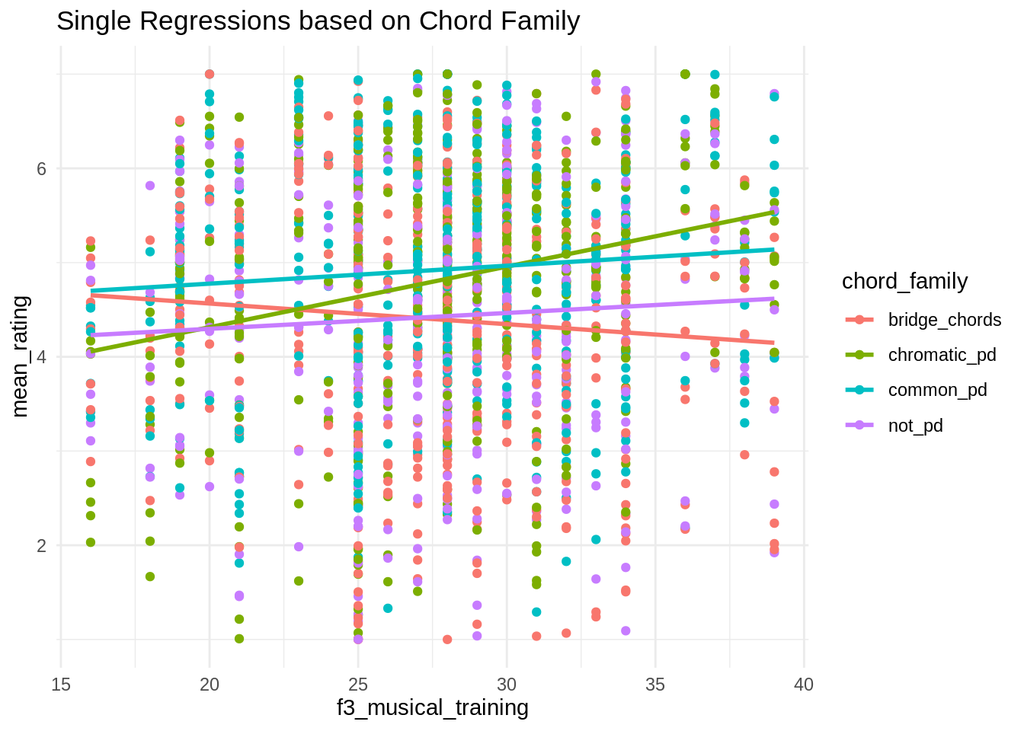

```r
avg_ratings %>%
  left_join(gmsi) %>%
  left_join(chord_stimuli_data) %>%
  select(mean_rating, sd_rating, chord_family, f3_musical_training ) %>%
  ggplot(aes(x = f3_musical_training, y = mean_rating, color = chord_family)) +
  geom_point() +
  theme_minimal() +
  geom_smooth(se = FALSE, method = "lm") +
  labs(title = "Single Regressions based on Chord Family")
```

```r
summary(model_x)
```

```
## Linear mixed model fit by REML. t-tests use Satterthwaite's method [
## lmerModLmerTest]
## Formula:
## rating ~ scale(f3_musical_training) + chord_family + (1 + chord_family |
##     participant) + (1 + scale(f3_musical_training) | participant)
##    Data: df
##
## REML criterion at convergence: 12614.1
##
## Scaled residuals:
##     Min      1Q  Median      3Q     Max
## -3.3740 -0.6058  0.0668  0.6851  3.1226
##
## Random effects:
##  Groups        Name                       Variance Std.Dev. Corr
##  participant   (Intercept)                0.08753  0.2959
##                chord_familybridge_chords  0.03906  0.1976   -0.13
##                chord_familycommon_pd      0.33513  0.5789   -0.83 -0.26
##                chord_familychromatic_pd   0.44119  0.6642   -0.82 -0.44  0.80
##  participant.1 (Intercept)                0.45930  0.6777
##                scale(f3_musical_training) 0.01016  0.1008   -1.00
##  Residual                                 1.69126  1.3005
## Number of obs: 3658, groups:  participant, 59
##
## Fixed effects:
##                            Estimate Std. Error       df t value Pr(>|t|)
## (Intercept)                 4.42817    0.10715 57.14183  41.327  < 2e-16 ***
## scale(f3_musical_training)  0.06838    0.08950 49.33254   0.764 0.448499
## chord_familybridge_chords  -0.03238    0.06709 58.44113  -0.483 0.631161
## chord_familycommon_pd       0.49659    0.09757 58.00584   5.090 4.06e-06 ***
## chord_familychromatic_pd    0.38572    0.10638 58.01182   3.626 0.000608 ***
## ---
## Signif. codes:  0 '***' 0.001 '**' 0.01 '*' 0.05 '.' 0.1 ' ' 1
##
## Correlation of Fixed Effects:
##              (Intr) s(3__) chrd_fmlyb_ chrd_fmlycm_
## scl(f3_ms_)  -0.235
## chrd_fmlyb_  -0.303  0.000
## chrd_fmlycm_ -0.426  0.000  0.237
## chrd_fmlych_ -0.418  0.000  0.150       0.703
## convergence code: 0
## boundary (singular) fit: see ?isSingular
```

```r
r.squaredGLMM(model_x)
```

```
##             R2m       R2c
## [1,] 0.02497869 0.2825936
```

```r
coef(model_x)
```

```
## $participant
##    (Intercept) scale(f3_musical_training) chord_familybridge_chords
## 1     4.380171               1.388139e-02              0.0509565824
## 2     4.946629               1.860905e-01              0.0959746417
## 3     4.822467              -8.444824e-02              0.0211306474
## 4     4.763817              -2.760381e-02              0.0038821853
## 5     4.602992              -8.503088e-02             -0.1011055243
## 6     4.715148               1.055263e-01              0.0994068128
## 7     5.135297               1.605041e-01              0.1522527066
## 8     4.609089               8.208021e-02              0.1035152884
## 9     4.368759              -7.829131e-03             -0.0345571837
## 10    4.822195               1.247153e-01              0.1363292297
## 11    4.455843               1.234217e-01             -0.0539894676
## 12    4.911447              -8.164881e-02              0.0010029162
## 13    4.869109               1.566523e-01              0.0986627182
```

[output cut: 109 more lines]

## Still to Do

- [ ] Experiment with Chordal 7th vs Parncutt Model
- [ ] Explore Other Models with Musical Features